# ST558 - Vignette Project - Covid-19 Data

Jasmine Wang

10/07/2021

```r
knitr::opts_chunk$set(fig.path = "../images/")
```

```r
rmarkdown::render("C:/Users/peach/Documents/ST558/ST558_repos/vignette_project/_Rmd/ST558_vignette_proj.Rmd",
                  output_format = "github_document",
                  output_file = "C:/Users/peach/documents/ST558/ST558_repos/vignette_project/README.md",
                  output_options = list(html_preview = FALSE, toc = TRUE, toc_depth = 3, df_print = "tibble")
)
```

## 1. Goal of Vignette

Since Covid-19 wide-spread the whole globe, most of people’s lives have been affected and even changed. However, with the administration of vaccination, we all hope to get back to the life it was like before. To do this, we need to get the majority population vaccination rate up to more than 70% for the community immunity to take effect. The purpose of this vignette is to see how the vaccination and state-mandated regulations have affected the active cases and deaths across the United States. Therefore, we are going to sum up all the active cases and deaths for each state and each month. Then, we will look at nite months of state-wide data about the active cases and deaths starting from January 2021.

We will divide the months into three different timelines:

- *Vaccinat-ING*: January, February, March, April
- *Some vaccinated*: May, June, July
- *Back to school*: August, September

During each timeline, we can see how the number of active cases and deaths are affected by these events.

The criteria I am using is based on vaccination progress in North Carolina. Since all groups are open to vaccination on April 7th, 2021, and it takes roughly four weeks to develop full immunity, I categorized the timeline before May to be on-going vaccination period while the antibodies against the virus are still developing. The months between May and July are when approximately 40% of the general population are vaccinated with at least one shot. Then, the students are going back to school in person in August and September. We will see how during these different timelines are the active cases and deaths changed in the exploratory data analysis section.

Therefore, the goal of this vignette is to create functions to help users query Covid-19 related data from [Covid-19 API site](https://covid19api.com) and parse the data into a nicely formatted tibble or data frame. Upon obtaining the data, we can then use it to perform some exploratory data analysis such as numerical summaries and plots for better visualization.

### 1.1. Required Packages

Below is a list of packages needed to create the vignette:

- `knitr`
- `httr`
- `jsonlite`
- `countrycode`
- `tidyverse`
- `ggplot2`

```r
library(knitr)
library(httr)
library(jsonlite)
library(tidyverse)
library(countrycode)

######## General summary/countries/all####################################################
general_input <- function(gen_input, ...){

  input1 <- tolower(gen_input, ...)
  option <- c("all", "summary", "countries")
  num <- charmatch(input1, option, ...)

  if(!is.na(num)) {

    status_string <- option[num]
    status_string

  } else {

    print("Sorry mate, your input is not valid! Please choose another one.")
  }
}

####### Country ###########################################################################
country <- function(country_name, ...){

  if(nchar(country_name) == 3) {

    nation_name <- countrycode(as.character(country_name), origin = "iso3c", destination = "country.name", ...)
    nation_name <- if_else(grepl(" ", nation_name, ignore.case = TRUE), tolower(sub(" ", "-", nation_name)), tolower(nation_name), ...)
    nation_name <- paste("country", nation_name, sep = "/", ...)
    nation_name

  } else if(nchar(country_name) == 2) {

    nation_name <- countrycode(as.character(country_name), origin = "iso2c", destination = "country.name", ...)
    nation_name <- if_else(grepl(" ", nation_name, ignore.case = TRUE), tolower(sub(" ", "-", nation_name)), tolower(nation_name), ...)
    nation_name <- paste("country", nation_name, sep = "/", ...)
    nation_name

  } else {

    nation_name <- if_else(grepl(" ", country_name, ignore.case = TRUE), tolower(sub(" ", "-", country_name)), tolower(country_name), ...)
    nation_name <- paste("country", nation_name, sep = "/", ...)
    nation_name
  }
}
#countrycode('Albania', origin = 'country.name', destination = 'iso3c')
#countrycode(nation, origin = "iso3c", destination = "country.name")

####### Status ### confirmed/recovered/deaths #####################################
status_input <- function(status, ...){

  input <- tolower(status, ...)
  option <- c("confirmed", "recovered", "deaths")
  num <- charmatch(input, option, ...)

  if(!is.na(num)) {

    status_string <- paste("status", option[num], sep="/", ...)
    status_string

  } else {

    print("Sorry mate, your input is not valid! Please choose another one.")
  }
}

####### Date Function ####################################################################
date_input_from <- function(date_from, ...){

  y <- c(date_from)
  y <- as_tibble(y)

  if(grepl("/", y$value, ignore.case = TRUE, ...)){

    temp <- y %>% separate(value, c("first", "second", "third"), sep="/", ...)

  } else if(grepl("-", y$value, ignore.case = TRUE, ...)) {

    temp <- y %>% separate(value, c("first", "second", "third"), sep="-", ...)

  } else {

    temp <- y %>% separate(value, c("first", "second", "third"), sep=" ", ...)
  }
  if(nchar(temp$first) == 4){

    if(nchar(temp$second) == 1){

      temp$second <- paste0("0", temp$second, ...)

      if(nchar(temp$third) == 1){

        temp$third <- paste0("0", temp$third, ...)
      }
    }
    temp <- unite(temp, date, first, second, third, sep="-", remove = TRUE, ...)
    temp$date

  } else {

    if(nchar(temp$second) == 1){

      temp$second <- paste0("0", temp$second, ...)

      if(nchar(temp$third) == 1){

        temp$third <- paste0("0", temp$third, ...)
      }
    }

    temp <- unite(temp, date, first, second, third, sep="-", remove = TRUE, ...)
    temp$date <- mdy(temp$date, ...)
    temp$date
  }
}

date_input_to <- function(date_to, ...){

  y <- c(date_to)
  y <- as_tibble(y)

  if(grepl("/", y$value, ignore.case = TRUE, ...)){

    temp <- y %>% separate(value, c("first", "second", "third"), sep="/", ...)

  } else if(grepl("-", y$value, ignore.case = TRUE, ...)) {

    temp <- y %>% separate(value, c("first", "second", "third"), sep="-", ...)

  } else {

    temp <- y %>% separate(value, c("first", "second", "third"), sep=" ", ...)
  }
  if(nchar(temp$first) == 4){

    if(nchar(temp$second) == 1){

      temp$second <- paste0("0", temp$second, ...)

      if(nchar(temp$third) == 1){

        temp$third <- paste0("0", temp$third, ...)
      }
    }
    temp <- unite(temp, date, first, second, third, sep="-", remove = TRUE, ...)
    temp$date

  } else {

    if(nchar(temp$second) == 1){

      temp$second <- paste0("0", temp$second, ...)

      if(nchar(temp$third) == 1){

        temp$third <- paste0("0", temp$third, ...)
      }
    }

    temp <- unite(temp, date, first, second, third, sep="-", remove = TRUE, ...)
    temp$date <- mdy(temp$date, ...)
    temp$date
  }
}

######### Time Function ##################################################################
time_input_from <- function(time_from, ...){

  times <- c(time_from)
  times <- as_tibble(times)

  if(grepl(":", times$value, ignore.case = TRUE, ...)) {

    times <- times %>% separate(value, c("first", "second", "third"), sep=":", ...)

  } else if(grepl("-", times$value, ignore.case = TRUE, ...)) {

    times <- times %>% separate(value, c("first", "second", "third"), sep="-", ...)

  } else if(grepl("/", times$value, ignore.case = TRUE, ...)) {

    times <- times %>% separate(value, c("first", "second", "third"), sep="/", ...)

  }

  if(nchar(times$first) == 1){

    times$first <- paste0("0", times$first, ...)

    if(nchar(times$second) == 1){

      times$second <- paste0("0", times$second, ...)

      if(nchar(times$third) == 1){

        times$third <- paste0("0", times$third, ...)

      }
    }
  }

  if(as.numeric(times$first) %in% c(0:23)){

    if(as.numeric(times$second) %in% c(0:59)){

      if(as.numeric(times$third) %in% c(0:59)){


        times <- unite(times, value, first, second, third, sep=":", remove = TRUE, ...)
        times$value

      } else {

        print("Sorry mate, your input is not valid! Please choose a time between 0 and 59 seconds.")

      }
    } else {

      print("Sorry mate, your input is not valid! Please choose a time between 0 and 59 minutes.")

    }
  } else {

    print("Sorry mate, your input is not valid! Please choose a military time between 0 and 23 hours.")

  }
}

time_input_to <- function(time_to, ...){

  times <- c(time_to)
  times <- as_tibble(times)

  if(grepl(":", times$value, ignore.case = TRUE, ...)) {

    times <- times %>% separate(value, c("first", "second", "third"), sep=":", ...)

  } else if(grepl("-", times$value, ignore.case = TRUE, ...)) {

    times <- times %>% separate(value, c("first", "second", "third"), sep="-", ...)

  } else if(grepl("/", times$value, ignore.case = TRUE, ...)) {

    times <- times %>% separate(value, c("first", "second", "third"), sep="/", ...)

  }

  if(nchar(times$first) == 1){

    times$first <- paste0("0", times$first, ...)

    if(nchar(times$second) == 1){

      times$second <- paste0("0", times$second, ...)

      if(nchar(times$third) == 1){

        times$third <- paste0("0", times$third, ...)

      }
    }
  }

  if(as.numeric(times$first) %in% c(0:23)){

    if(as.numeric(times$second) %in% c(0:59)){

      if(as.numeric(times$third) %in% c(0:59)){


        times <- unite(times, value, first, second, third, sep=":", remove = TRUE, ...)
        times$value

      } else {

        print("Sorry mate, your input is not valid! Please choose a time between 0 and 59 seconds.")

      }
    } else {

      print("Sorry mate, your input is not valid! Please choose a time between 0 and 59 minutes.")

    }
  } else {

    print("Sorry mate, your input is not valid! Please choose a military time between 0 and 23 hours.")

  }
}

############# A P I ##########################################################################
ref_general <- function(gen_input = "countries", ...){

  info1 <- general_input(gen_input, ...)

  api_url <- if_else(info1 %in% c("all", "summary", "countries"),
                     paste("https://api.covid19api.com", info1, sep = "/"), info1, ...)
  api_url

}

dayone_all_status <- function(country_name = "BB", ...){

  info2 <- country(country_name, ...)

  api_url <- paste("https://api.covid19api.com/dayone", info2, sep = "/", ...)
  api_url

}

dayone_status <- function(country_name = "BB", status = "confirmed", ...){

  info2 <- country(country_name, ...)
  info3 <- status_input(status, ...)

  api_url <- paste("https://api.covid19api.com/dayone", info2, info3, sep = "/", ...)
  api_url

}

dayone_status_live <- function(country_name = "BB", status = "confirmed", ...){

  info2 <- country(country_name, ...)
  info3 <- status_input(status, ...)

  api_url <- paste("https://api.covid19api.com/dayone", info2, info3, "live", sep = "/", ...)
  api_url

}

datetime_specific_all_status <- function(country_name="BB", date_from="2020-05-01", date_to="2020-05-03",
                                             time_from="00:00:00", time_to="00:00:00", ...){

  info2 <- country(country_name, ...)

  date1 <- date_input_from(date_from, ...)
  date2 <- date_input_to(date_to, ...)
  time1 <- time_input_from(time_from, ...)
  time2 <- time_input_to(time_to, ...)

  latter <- paste0("?from=", date1, "T", time1, "Z&to=", date2, "T", time2, "Z", ...)
  api_url <- paste0("https://api.covid19api.com/", info2, latter, ...)
  api_url

}

datetime_specific_status <- function(country_name="BB", status="confirmed", date_from="2020-05-01", date_to="2020-05-03",
                                         time_from="00:00:00", time_to="00:00:00", ...){

  info2 <- country(country_name, ...)
  info3 <- status_input(status, ...)

  date1 <- date_input_from(date_from, ...)
  date2 <- date_input_to(date_to, ...)
  time1 <- time_input_from(time_from, ...)
  time2 <- time_input_to(time_to, ...)

  latter <- paste0("?from=", date1, "T", time1, "Z&to=", date2, "T", time2, "Z", ...)
  api_url <- paste0("https://api.covid19api.com/", info2, "/", info3, latter, ...)
  api_url

}

live_all_status <- function(country_name = "BB", ...){

    info2 <- country(country_name, ...)

  api_url <- paste("https://api.covid19api.com/live", info2, sep = "/", ...)
  api_url

}

live_status <- function(country_name = "BB", status = "confirmed", ...){

  info2 <- country(country_name, ...)
  info3 <- status_input(status, ...)

  api_url <- paste("https://api.covid19api.com/live", info2, info3, sep = "/", ...)
  api_url

}

live_status_after_date <- function(country_name = "BB", status = "confirmed",
                                   date_from="2020-05-01", time_from="00:00:00", ...){

  info2 <- country(country_name, ...)
  info3 <- status_input(status, ...)

  date1 <- date_input_from(date_from, ...)
  time1 <- time_input_from(time_from, ...)
  datetime <- paste0(date_from, "T", time_from, "Z", ...)

  api_url <- paste("https://api.covid19api.com/live", info2, info3, "date", datetime,  sep = "/", ...)
  api_url

}
```

## 2. Customized Functions

I created some customized functions implemented with some user-friendly input arguments to query the Covid-19 data from [Covid-19 API](https://covid19api.com/). Then, I created a wrapper function, `choose_api`, which contains those nine customized functions to obtain the correct API URL to query the data needed for the users. Users would only need to supply with arguments like the country they want to query from, status of the query (total confirmed cases, recovered cases, or number of deaths), and starting from certain date and time they want to query the data. Users can use `choose_api` function to check if their query API URL is correct to query the data they need. Then, they can use the exact same arguments they used in the `choose_api` function in the `get_data` function to obtain the parsed data in a usable form. Thus, if the API URL obtained from `choose_api` function is not correct, those same arguments are surely not going to work in the `get_data` function. Therefore, `choose_api` function is a way to make sure if the user-supplied arguments are correct, and the obtained API URL is what the users want to query.

### 2.1. A List of Customized Functions

Let’s look at the options of the data the customized functions can query:

1. **general** option, `ref_general` function:
   - *summary* returns a summary of new and total cases per country, updated daily.
   - *countries* returns all the available countries and provinces, and the country slug for per country requests.
   - *all* returns all daily data. WARNING: This call results in > 10MB of data being returned and should be used infrequently.
   - `choose_api(type = 1, gen_input = "summary")`
   - https://api.covid19api.com/summary
2. **option1** API, `dayone_all_status`:
   - Returns all cases types including confirmed cases, recovered cases and deaths for a country from the first recorded case.
   - `choose_api(type = 2, country_name = "barbados")`
   - https://api.covid19api.com/dayone/country/barbados
3. **option2** API, `dayone_status`:
   - Returns cases by case type for a country from the first recorded case. Case types must be one of confirmed, recovered or deaths.
   - `choose_api(type = "option2", country_name = "barbados", status = "confirmed")`
   - https://api.covid19api.com/dayone/country/barbados/status/confirmed
4. **option3** API, `dayone_status_live`:
   - Returns cases by case type for a country from the first recorded case with the latest record being the live count. Case types must be one of confirmed, recovered or deaths.
   - `choose_api(type = "option3", country_name = "barbados", status = "confirmed")`
   - https://api.covid19api.com/dayone/country/barbados/status/confirmed/live
5. **option4** API, `datetime_specific_all_status`:
   - Returns all cases types including confirmed cases, recovered cases and deaths for a country. Date and time can vary and be chosen by users.
   - `choose_api(type = 5, country_name = "barbados", date_from = "2020-05-01", date_to = "2020-05-03", time_from = "00:00:00", time_to = "00:00:00")`
   - https://api.covid19api.com/country/barbados?from=2020-05-01T00:00:00Z&to=2020-05-03T00:00:00Z
6. **option5** API, `datetime_specific_status`:
   - Returns cases by case type for a country. Date and time can vary and be chosen by users. Case types must be one of confirmed, recovered or deaths.
   - `choose_api(type = "option5", country_name = "barbados", status = "confirmed", date_from = "2020-05-01", date_to = "2020-05-03", time_from = "00:00:00", time_to = "00:00:00")`
   - https://api.covid19api.com/country/barbados/status/confirmed?from=2020-05-01T00:00:00Z&to=2020-05-03T00:00:00Z
7. **option6** API, `live_all_status`:
   - Returns all live cases types including confirmed cases, recovered cases and deaths for a country. These records are pulled every 10 minutes and are ungrouped.
   - `choose_api(type = 7, country_name = "barbados")`
   - https://api.covid19api.com/live/country/barbados
8. **option7** API, `live_status`:
   - Returns live cases by case type for a country. These records are pulled every 10 minutes and are ungrouped. Case types must be one of confirmed, recovered or deaths.
   - `choose_api(type = 8, country_name = "barbados", status = "confirmed")`
   - https://api.covid19api.com/live/country/barbados/status/confirmed
9. **option8** API, `live_status_after_date`:
   - Returns live cases by case type for a country after a given date/time. These records are pulled every 10 minutes and are ungrouped. Case types must be one of confirmed, recovered or deaths.
   - `choose_api(type = "option8", country_name = "barbados", status = "confirmed", date_from = "2020-05-01", time_from = "00:00:00")`
   - https://api.covid19api.com/live/country/barbados/status/confirmed/date/2020-05-01T00:00:00Z

Simply use `choose_api(type, ...)` to get the desired API URL. Use argument, `type = 1` or `type = "general"`, to select the customized API function call for a summary or a list of available countries or all data. Use `type = 2` or `type = "option1"` to obtain the API URL for all cases types for a country since the first recorded case.

If more argument inputs are needed, subsequent order of the arguments is:

- “type” -> “country” -> “status” -> “date from” -> “date to” -> “time from” -> “time to”

If the desired API URL the users get from the `choose_api` function is correct, the same exact arguments used in `choose_api` should be used again in `get_data` function to query the data from Covid-19 API site. For more information about what the API URL should look like, please visit the [Covid-19 API site](https://documenter.getpostman.com/view/10808728/SzS8rjbc).

```r
choose_api <- function(type, ...) {

  switch(type,

         general = ref_general(...),
         option1 = dayone_all_status(...),
         option2 = dayone_status(...),
         option3 = dayone_status_live(...),
         option4 = datetime_specific_all_status(...),
         option5 = datetime_specific_status(...),
         option6 = live_all_status(...),
         option7 = live_status(...),
         option8 = live_status_after_date(...)
  )
}

get_data <- function(type, ...){

  api_url <- choose_api(type, ...)
  json_data <- GET(api_url)
  extract_data <- rawToChar(json_data$content)
  usable_form <- fromJSON(extract_data)
  usable_form

}
```

### 2.2. A List of Input Arguments and their Defaults

The table below show a list of customized API functions with their corresponding arguments and defaults set.

| Function(s) | Argument(s) | Default(s) |
| --- | --- | --- |
| `ref_general` | `gen_input` | None for `gen_input` |
| `dayone_all_status` | `country_name` | `country_name = "BB"` |
| `dayone_status` | `country_name`, `status` | `status = "confirmed"` |
| `dayone_status_live` | `country_name`, `status` | `date_from = "2020-05-01"` |
| `datetime_specific_all_status` | `country_name`, `date_from`, `date_to`, `time_from`, `time_to` | `date_to = "2020-05-03"` |
| `datetime_specific_status` | `country_name`, `status`, `date_from`, `date_to`, `time_from`, `time_to` | `time_from = "00:00:00"` |
| `live_all_status` | `country_name` | `time_to = "00:00:00"` |
| `live_status` | `country_name`, `status` |  |
| `live_status_after_date` | `country_name`, `status`, `date_from`, `time_from` |  |

Let’s look at the options each argument can take:

1. `gen_input`:
   - Can take or partially match these options, `"summary"`, `"countries"`, `"all"` (or “Su”, “SuM”, “sUmMa”). Non-case sensitive.
   - I did not set a default value for `gen_input` function because using the API URL generated by this function will query a large data set and will be time-consuming. Therefore, unless the users really want to query from these options, I do not want them to accidentally set it off. In a word, if the users really want to query from these options, they can input those arguments themselves. Otherwise, I would recommend to go to the [Covid-19 API site](https://documenter.getpostman.com/view/10808728/SzS8rjbc#00030720-fae3-4c72-8aea-ad01ba17adf8) to see the example lists from these options.
2. `country_name`:
   - Must be the slug country name from the available list or 2-letter (ISO2) or 3-letter (ISO3) abbreviations.
   - For example, “uNitED-sTATes”, “UnItEd StAtES”, “uSa” and “uS” are all valid inputs. Non-case sensitive.
   - Default country is Barbados.
3. `status`:
   - Can take or partially match these options, `"confirmed"`, `"recovered"`, `"deaths"` (or “Co”, “cOn”, “cOnf”). Non-case sensitive.
   - Default status is “confirmed”.
4. `date_from` and `date_to`:
   - Can take “2020 12 31”, “12/31/2021”, “2020-12-31”, “3 20 2021”, “2020 10 6”.
   - Note: If users request data from dates that are before Covid-19 time for a country, i.e. 2018, this may result in an error or the data contains all zero lists.
   - Default for `date_from` is “2020-05-01” and for `date_to` is “2020-05-03”.
5. `time_from` and `time_to`:
   - *Hour* can take any numeric values from 0 to 23 (must be in military time).
   - *Minute* can take any numeric values from 0 to 59.
   - *second* can take any numeric values from 0 to 59.
   - Can take “1:4:5”, “1/4/5”, “1-4-5” (all equivalent to “01:04:05”).
   - Default for both `time_from` and `time_to` is "00:00:00:

**Note: If users do not supply any argument inputs but simply choose an option function to guery the data, it will return cases results for Barbados from May 1st, 2020, at time 00:00:00 to May 3rd, 2020, at time 00:00:00.**

**Note 2: Free API query does not require a key for the Covid-19 API site. However, free queries have limited access and functionality. For example, free queries can only query up to a week of data at once. So, if you need to query a month of data. you will have to run the query four times with different date inputs.**

### 2.3 Using an API

Below is the API URL used with `get_data` function I created to query the data for all cases type for the United States from January 3rd, 2021 to January 5th, 2021 (3 days). We can see it returns for 10,000 rows and 13 columns including every city from every state in the United States for 3 days worth of all cases type of data. I realized by looking at this example data that all cases types are accumulated up untill the date/time queried. If I want to calculate all cases types for each month for each state in the United States, I can query one day of data at the end of each month, group by each state and sum up all different cases type, subtract them from the previous end of month one day data. Then, we will have the number of all cases types per state per month, not cumulatively. Let’s see if this works!

```r
choose_api(5, "usa", date_from="2021 1 3", date_to="2021 1 5", time_to="23:59:59")
```

```
## [1] "https://api.covid19api.com/country/united-states?from=2021-01-03T00:00:00Z&to=2021-01-05T23:59:59Z"
```

```r
test_data <- get_data(5, "usa", date_from="2021 1 3", date_to="2021 1 5", time_to="23:59:59")
test_data <- test_data %>% group_by(City)
test_data
```

```
## # A tibble: 10,011 x 13
## # Groups:   City [1,975]
##    ID        Country   CountryCode Province City  CityCode Lat   Lon   Confirmed
##    <chr>     <chr>     <chr>       <chr>    <chr> <chr>    <chr> <chr>     <int>
##  1 00055249~ United S~ US          Texas    Hend~ 48213    32.21 -95.~      3675
##  2 000f161d~ United S~ US          New Mex~ Torr~ 35057    34.64 -105~       498
##  3 00591a34~ United S~ US          Oklahoma Pitt~ 40121    34.92 -95.~      3184
##  4 009f4dd8~ United S~ US          Arkansas Mill~ 5091     33.31 -93.~      2818
##  5 00b299cb~ United S~ US          Mississ~ Tate  28137    34.65 -89.~      2441
##  6 00d8ef35~ United S~ US          Illinois Wayne 17191    38.43 -88.~      1358
##  7 00eb8717~ United S~ US          Virginia Carr~ 51035    36.73 -80.~      1534
##  8 0105b524~ United S~ US          South D~ Auro~ 46003    43.72 -98.~       414
##  9 0105d892~ United S~ US          Tenness~ Laud~ 47097    35.76 -89.~      2702
## 10 012b834c~ United S~ US          New Jer~ Camd~ 34007    39.8  -74.~     32243
## # ... with 10,001 more rows, and 4 more variables: Deaths <int>,
## #   Recovered <int>, Active <int>, Date <chr>
```

## 3. Getting the Data

### 3.1. Combining Date Sets

Since the free Covid-19 data query does not require a key and has limited access/queries. For instance, each time we make a request to query, we can only query data for a range up to a week. Thus, I made a single-day query for the last day of each month from December 2020 to September 2021 since the data is accumulated. I only selected five columns (*Province*, *Confirmed*, *Deaths*, *Active*, *Date*) from each query and saved them to an object named by a month of that query. I row-combined those objects/queries into two different data sets since they all have the same column names. This way I did so that I can column-combine them later and subtract the same case type for each state for each month.

The data set I had in mind eventually should look like the example table shown below so that I can compute the following tasks.

- Total confirmed cases/month, state = Confirmed_cases - Confirmed_cases2
- Total number of deaths/month, state = Deaths_1 - Deaths_2 …

| Province | Confirmed_cases | Confirmed_cases2 | Deaths_1 | Deaths_2 | Month |
| --- | --- | --- | --- | --- | --- |
| North Carolina | 4569 (Jan 2021) | 4123 (Dec 2020) | 568 (Jan 2021) | 538 (Dec 2020) | January |
| North Carolina | 5638 (Feb 2021) | 4569 (Jan 2021) | 588 (Feb 2021) | 568 (Jan 2021) | February |
| North Carolina | 5883 (Mar 2021) | 5638 (Feb 2021) | 638 (Mar 2021) | 588 (Feb 2021) | March |

…

```r
dec <- get_data(5, "usa", date_from="2020 12 31", date_to="2020 12 31", time_to="23:59:59")
jan <- get_data(5, "usa", date_from="2021 1 31", date_to="2021 1 31", time_to="23:59:59")
feb <- get_data(5, "usa", date_from="2021 2 28", date_to="2021 2 28", time_to="23:59:59")
mar <- get_data(5, "usa", date_from="2021 3 31", date_to="2021 3 31", time_to="23:59:59")
apr <- get_data(5, "usa", date_from="2021 4 30", date_to="2021 4 30", time_to="23:59:59")
may <- get_data(5, "usa", date_from="2021 5 31", date_to="2021 5 31", time_to="23:59:59")
jun <- get_data(5, "usa", date_from="2021 6 30", date_to="2021 6 30", time_to="23:59:59")
jul <- get_data(5, "usa", date_from="2021 7 31", date_to="2021 7 31", time_to="23:59:59")
aug <- get_data(5, "usa", date_from="2021 8 31", date_to="2021 8 31", time_to="23:59:59")
sep <- get_data(5, "usa", date_from="2021 9 30", date_to="2021 9 30", time_to="23:59:59")

dec_2 <- dec %>% select(Province, Confirmed, Deaths, Active, Date)
jan_2 <- jan %>% select(Province, Confirmed, Deaths, Active, Date)
feb_2 <- feb %>% select(Province, Confirmed, Deaths, Active, Date)
mar_2 <- mar %>% select(Province, Confirmed, Deaths, Active, Date)
apr_2 <- apr %>% select(Province, Confirmed, Deaths, Active, Date)
may_2 <- may %>% select(Province, Confirmed, Deaths, Active, Date)
jun_2 <- jun %>% select(Province, Confirmed, Deaths, Active, Date)
jul_2 <- jul %>% select(Province, Confirmed, Deaths, Active, Date)
aug_2 <- aug %>% select(Province, Confirmed, Deaths, Active, Date)
sep_2 <- sep %>% select(Province, Confirmed, Deaths, Active, Date)

late_date <- rbind(jan_2, feb_2, mar_2, apr_2, may_2, jun_2, jul_2, aug_2, sep_2)
early_date <- rbind(dec_2, jan_2, feb_2, mar_2, apr_2, may_2, jun_2, jul_2, aug_2)
```

## 4. Data Manipulation

At this point, I have data from every city in each state. So, I grouped by *Province* and *Date* and sum up all different case types for each state for the same date. I applied this to both data sets. Then, I changed the names of the columns in one of the datasets in order to perform a column-combination of the two tables afterwards and saved it as an object, *mydata1*. Now, *mydata1* is in a format I had in mind earlier as shown in the table above.

```r
after_date <- late_date %>% group_by(Province, Date) %>% summarise(across(c(Confirmed, Deaths, Active), sum))
before_date <- early_date %>% group_by(Province, Date) %>% summarise(across(c(Confirmed, Deaths, Active), sum))

names(before_date) <- c("State", "Date2", "Confirmed2", "Deaths2", "Active2")
mydata1 <- cbind(after_date, before_date)
alldata <- mydata1[1:9, ]
mydata1 <- mydata1[-1:-9, ]
mydata1
```

```
## # A tibble: 522 x 10
## # Groups:   Province [58]
##    Province Date  Confirmed Deaths Active State Date2 Confirmed2 Deaths2 Active2
##    <chr>    <chr>     <int>  <int>  <int> <chr> <chr>      <int>   <int>   <int>
##  1 Alabama  2021~    459639   7688 451951 Alab~ 2020~     361226    4827  356399
##  2 Alabama  2021~    493252   9929 483323 Alab~ 2021~     459639    7688  451951
##  3 Alabama  2021~    515388  10554 504834 Alab~ 2021~     493252    9929  483323
##  4 Alabama  2021~    527922  10896 517026 Alab~ 2021~     515388   10554  504834
##  5 Alabama  2021~    543405  11146 532259 Alab~ 2021~     527922   10896  517026
##  6 Alabama  2021~    550983  11352 539631 Alab~ 2021~     543405   11146  532259
##  7 Alabama  2021~    585607  11536 574071 Alab~ 2021~     550983   11352  539631
##  8 Alabama  2021~    699729  12283 687446 Alab~ 2021~     585607   11536  574071
##  9 Alabama  2021~    796475  14299 782176 Alab~ 2021~     699729   12283  687446
## 10 Alaska   2021~     54350    262  54088 Alas~ 2020~      47014     206   46808
## # ... with 512 more rows
```

### 4.1. Creating Numeric Variables

Now we are ready to subtract each case type from itself from the previous month and obtain the total number of confirmed cases, active cases and deaths for each month for each state. Then, we can compare those numbers between different states.

Four variables are created here, and we do not keep the old variables we used to compute the new ones. These variables are now representative numbers for the corresponding month and state. They are no longer the cumulative figures.

- *Total*
- *Month*
- *Deaths*
- *Active*

You can also save this data to your local drive in case of an unexpected event occurred such as website maintenance.

```r
mydata2 <- mydata1 %>% mutate(Total = Confirmed - Confirmed2, Death = Deaths - Deaths2, Active_cases = Active - Active2,
                              Month = rep(c("Jan", "Feb", "Mar", "Apr", "May", "Jun", "Jul", "Aug", "Sep"))) %>%
  select(State, Month, Total, Death, Active_cases)
names(mydata2) <- c("Province","State", "Month", "Total", "Deaths", "Active")
mydata2
```

```
## # A tibble: 522 x 6
## # Groups:   Province [58]
##    Province State   Month  Total Deaths Active
##    <chr>    <chr>   <chr>  <int>  <int>  <int>
##  1 Alabama  Alabama Jan    98413   2861  95552
##  2 Alabama  Alabama Feb    33613   2241  31372
##  3 Alabama  Alabama Mar    22136    625  21511
##  4 Alabama  Alabama Apr    12534    342  12192
##  5 Alabama  Alabama May    15483    250  15233
##  6 Alabama  Alabama Jun     7578    206   7372
##  7 Alabama  Alabama Jul    34624    184  34440
##  8 Alabama  Alabama Aug   114122    747 113375
##  9 Alabama  Alabama Sep    96746   2016  94730
## 10 Alaska   Alaska  Jan     7336     56   7280
## # ... with 512 more rows
```

```r
# write_csv(x = mydata2, path = "../_Data/covid_data.csv")
```

### 4.2. Creating Categorical Variables

I used `mutate` function to create three categorical variables using the numerical variables we just obtained.

- *f500_deaths* (2 levels):
  - Less than 500 deaths
  - More than 500 deaths
- *Total_cases* (3 levels):
  - Less than 9,000 cases
  - Between 9,000 and 30,000 cases
  - More than 30,000 cases
- *vaccine* (3 levels):
  - Vaccinat-ING (Jan, Feb, Mar, Apr)
  - Some vaccinated (May, Jun, Jul)
  - Back to school (Aug, Sep)

```r
`%!in%` <- Negate(`%in%`)

mydata3 <- mydata2 %>% filter(Province %!in% c("American Samoa", "Diamond Princess", "Grand Princess", "Guam", "Northern Mariana Islands", "Puerto Rico", "Virgin Islands", " ")) %>%
  mutate(f500_deaths = if_else(Deaths < 500, 1, 2),
         Total_cases = if_else(Total < 9000, 1,
                             if_else(Total < 30000, 2, 3)),
         vaccine = if_else(Month %in% c("Jan", "Feb", "Mar", "Apr"), 1,
                           if_else(Month %in% c("May", "Jun", "Jul"), 2, 3)))

mydata3$f500_deaths <- cut(mydata3$f500_deaths, 2, c("Less than 500 deaths", "More than 500 deaths"))
mydata3$Total_cases <- cut(mydata3$Total_cases, 3, c("Less than 9,000 cases", "Between 9,000 and 30,000 cases", "More than 30,000 cases"))
mydata3$vaccine <- cut(mydata3$vaccine, 3, c("Vaccinat-ING", "Some vaccinated", "Back to school"))
```

## 5. Exploratory Data Analysis

### 5.1. Contingency Tables

Now we have 51 states, and each state has nine months worth of data. Therefore, 51 x 9 = 459 rows in the data. Each event in Table 1 represents one state and one month. However, since “vaccinat-ing” period has 4 months, “Some vaccinated” period contains 3 months and “Back to school” period only has 2 months, the data is not on a even scale for the three categories. Hence, we cannot compare them across columns. We can only compare them down the rows within each column.

Table 2 and Table 3 show the total confirmed cases and total number of deaths between the states known to have the most cases from January to September 2021 compared to North Carolina. One interesting finding is that the number of total confirmed cases were slowly dropping for each state during “vaccinat-ing” period and then reached the minimum number of cases of all time during “some vaccinated” period. However, that number went back up when students went back to schools. The number total confirmed cases were almost equivalent to those numbers back in January for most states. This is why state of North Carolina reinforced the mask mandate again in August 2021.

Since there are more cases in each state, there will be more deaths. If the number of cases are less, the number of deaths will be less in each state as well. It is difficult to see this in a table. Let’s visualize these data with different plots in the plots section.

```r
# 1st contingency table
table(mydata3$Total_cases, mydata3$vaccine) %>% kable(caption = "Table 1. Total Confirmed Cases vs. Vaccine Timeline")
```

Table 1. Total Confirmed Cases vs. Vaccine Timeline

|  | Vaccinat-ING | Some vaccinated | Back to school |
| --- | --- | --- | --- |
| Less than 9,000 cases | 46 | 79 | 10 |
| Between 9,000 and 30,000 cases | 63 | 51 | 24 |
| More than 30,000 cases | 95 | 23 | 68 |

```r
# 2nd contingency table
mydata3 %>% filter(Province %in% c("California", "New York", "Florida", "Texas", "Michigan", "North Carolina")) %>%
  select(Province, Month, Deaths) %>%
  pivot_wider(names_from = "Month", values_from = "Deaths") %>% arrange(desc(Jan)) %>%
  kable(caption = "Table 2. Number of Deaths for Each Month across Different States")
```

Table 2. Number of Deaths for Each Month across Different States

| Province | Jan | Feb | Mar | Apr | May | Jun | Jul | Aug | Sep |
| --- | --- | --- | --- | --- | --- | --- | --- | --- | --- |
| California | 14994 | 11621 | 6373 | 2463 | 1263 | 813 | 888 | 1448 | 3257 |
| Texas | 9008 | 6623 | 4555 | 1967 | 1289 | 829 | 940 | 3767 | 8159 |
| New York | 5651 | 3967 | 2680 | 1958 | 1043 | 372 | 171 | 613 | 1104 |
| Florida | 4806 | 4373 | 2573 | 1736 | 1613 | 998 | 1307 | 5482 | 10448 |
| North Carolina | 2587 | 1877 | 900 | 539 | 427 | 359 | 198 | 833 | 2056 |
| Michigan | 2489 | 977 | 610 | 1629 | 1627 | 620 | 187 | 359 | 808 |

```r
# 3rd contingency table
mydata3 %>% filter(Province %in% c("California", "New York", "Florida", "Texas", "Michigan", "North Carolina")) %>%
  select(Province, Month, Total) %>%
  pivot_wider(names_from = "Month", values_from = "Total") %>% arrange(desc(Jan)) %>%
  kable(caption = "Table 3. Total Confirmed Cases for Each Month across Different States")
```

Table 3. Total Confirmed Cases for Each Month across Different States

| Province | Jan | Feb | Mar | Apr | May | Jun | Jul | Aug | Sep |
| --- | --- | --- | --- | --- | --- | --- | --- | --- | --- |
| California | 997110 | 241898 | 100463 | 76039 | 49031 | 29059 | 148305 | 432125 | 268073 |
| Texas | 603560 | 276669 | 138897 | 102018 | 59481 | 46660 | 138768 | 473409 | 456018 |
| New York | 441124 | 223960 | 229271 | 175012 | 54254 | 12582 | 35404 | 128200 | 148093 |
| Florida | 398062 | 187844 | 148514 | 175783 | 87300 | 44646 | 268770 | 616220 | 332353 |
| North Carolina | 217981 | 101022 | 55584 | 55620 | 31402 | 12535 | 34387 | 165578 | 181600 |
| Michigan | 78775 | 34297 | 99685 | 189525 | 55110 | 8209 | 11064 | 49187 | 89646 |

### 5.2. Numerical Summaries

Table 4 and Table 5 shows the numerical summaries of active cases and deaths during each vaccine timeline for North Carolina and its neighbors. North Carolina was placed pretty high regarding to the active cases for each timeline right below Georgia, followed by Tennessee. Shockingly, the average active cases for “back to school” period all exceeded the average active cases for “vaccinat-ing” period for every state with Virginia being a close-call. The number was almost doubled for some states or more than doubled for Tennessee. This indicates that “back to school” event drove the number of cases up in each state and counterattacked the great effect brought by wide-spread vaccine administration. The effect of vaccine is shown in the “some vaccinated” period that drove the average active cases down.

However, the effect of “going back to school” event is not as dramatic as shown in Table 4 as in Table 5. The number of deaths did go up during “back to school” period due to elevated number of active cases in the same period, however, that number was not almost doubled or doubled. They were only matching or even. This could be the vaccines were developing antibodies and immunity in our body, and hence, the infected individuals had a better chance to fight the virus and survived during “back to school” period. People should really get their vaccine shots if they have not already.

```r
mydata3 %>% filter(Province %in% c("North Carolina", "South Carolina", "Tennessee","Georgia", "Virginia")) %>%
  group_by(Province, vaccine) %>%
  summarise(Avg_active = mean(Active), SD_active = sd(Active), Median_active = median(Active), IQR_active = IQR(Active)) %>%
  kable(digit = 2, caption = "Table 4. Active cases per vaccine timeline for North Carolina and its neighbors.")
```

Table 4. Active cases per vaccine timeline for North Carolina and its neighbors.

| Province | vaccine | Avg_active | SD_active | Median_active | IQR_active |
| --- | --- | --- | --- | --- | --- |
| Georgia | Vaccinat-ING | 106119.75 | 92096.53 | 72623.0 | 82090.25 |
| Georgia | Some vaccinated | 25925.33 | 17422.78 | 23007.0 | 17238.50 |
| Georgia | Back to school | 197429.50 | 36259.73 | 197429.5 | 25639.50 |
| North Carolina | Vaccinat-ING | 106076.00 | 75806.97 | 77113.0 | 73225.50 |
| North Carolina | Some vaccinated | 25780.00 | 11890.50 | 30975.0 | 11006.50 |
| North Carolina | Back to school | 172144.50 | 10464.47 | 172144.5 | 7399.50 |
| South Carolina | Vaccinat-ING | 66737.75 | 49099.03 | 53070.0 | 55158.25 |
| South Carolina | Some vaccinated | 12694.00 | 8488.12 | 14364.0 | 8364.00 |
| South Carolina | Back to school | 118835.00 | 1965.76 | 118835.0 | 1390.00 |
| Tennessee | Vaccinat-ING | 63834.50 | 49860.35 | 40863.5 | 32533.00 |
| Tennessee | Some vaccinated | 15199.00 | 11000.60 | 14727.0 | 10993.00 |
| Tennessee | Back to school | 166274.00 | 12406.90 | 166274.0 | 8773.00 |
| Virginia | Vaccinat-ING | 76067.00 | 53515.94 | 55204.5 | 49384.50 |
| Virginia | Some vaccinated | 11344.00 | 5918.52 | 13927.0 | 5479.50 |
| Virginia | Back to school | 85587.00 | 19581.20 | 85587.0 | 13846.00 |

```r
mydata3 %>% filter(Province %in% c("North Carolina", "South Carolina", "Tennessee","Georgia", "Virginia")) %>%
  group_by(Province, vaccine) %>%
  summarise(Average = mean(Deaths), SD = sd(Deaths), Median = median(Deaths), IQR = IQR(Deaths)) %>%
  kable(digit = 2, caption = "Table 5. Number of deaths per vaccine timeline for North Carolina and its neighbors.")
```

Table 5. Number of deaths per vaccine timeline for North Carolina and its neighbors.

| Province | vaccine | Average | SD | Median | IQR |
| --- | --- | --- | --- | --- | --- |
| Georgia | Vaccinat-ING | 2314.00 | 1034.82 | 2428.5 | 1535.00 |
| Georgia | Some vaccinated | 495.33 | 212.07 | 586.0 | 197.00 |
| Georgia | Back to school | 2204.00 | 1612.20 | 2204.0 | 1140.00 |
| North Carolina | Vaccinat-ING | 1475.75 | 931.82 | 1388.5 | 1244.75 |
| North Carolina | Some vaccinated | 328.00 | 117.61 | 359.0 | 114.50 |
| North Carolina | Back to school | 1444.50 | 864.79 | 1444.5 | 611.50 |
| South Carolina | Vaccinat-ING | 1050.25 | 678.63 | 1052.0 | 1026.75 |
| South Carolina | Some vaccinated | 135.67 | 89.49 | 85.0 | 78.00 |
| South Carolina | Back to school | 1284.00 | 834.39 | 1284.0 | 590.00 |
| Tennessee | Vaccinat-ING | 1322.50 | 1148.63 | 1127.0 | 1563.50 |
| Tennessee | Some vaccinated | 175.67 | 62.63 | 162.0 | 61.50 |
| Tennessee | Back to school | 1209.00 | 643.47 | 1209.0 | 455.00 |
| Virginia | Vaccinat-ING | 1434.50 | 667.72 | 1566.0 | 593.50 |
| Virginia | Some vaccinated | 254.00 | 151.06 | 229.0 | 149.50 |
| Virginia | Back to school | 609.00 | 422.85 | 609.0 | 299.00 |

### 5.3. Visualization

#### 5.3.1. Bar-Plots

We combined with the findings we learnt from Table 1, Table 2 and Table 3 and showed them in Figure 1 and Figure 2 below.

Again, the wide-spread vaccine administration across US is working, and those individuals who received shots are developing antibodies against the virus. Thus, the average number of deaths was not elevated for most states even when students were going back to school.

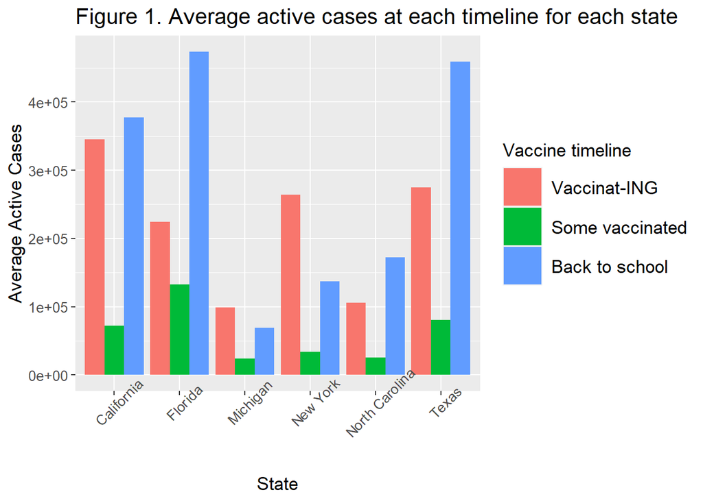

```r
barplot1 <- mydata3 %>% filter(Province %in% c("California", "New York", "Florida", "Texas", "Michigan", "North Carolina")) %>%
  group_by(Province, vaccine) %>%
  summarise(Avg_active = mean(Active), SD_active = sd(Active), Median_active = median(Active), IQR_active = IQR(Active))
barplot2 <- mydata3 %>% filter(Province %in% c("California", "New York", "Florida", "Texas", "Michigan", "North Carolina")) %>%
  group_by(Province, vaccine) %>%
  summarise(Average = mean(Deaths), SD = sd(Deaths), Median = median(Deaths), IQR = IQR(Deaths))
g <- ggplot(data = barplot1, aes(x = Province, y = Avg_active, fill = vaccine))
g + geom_bar(stat = "identity", position = "dodge") +
  labs(x = "State", y = "Average Active Cases", title = "Figure 1. Average active cases at each timeline for each state") +
  scale_fill_discrete(name = "Vaccine timeline") +
  theme(axis.text.x = element_text(angle = 45, size = 10),
        axis.text.y = element_text(size = 10),
        axis.title.x = element_text(size = 13),
        axis.title.y = element_text(size = 13),
        legend.key.size = unit(1, 'cm'),
        legend.text = element_text(size = 13),
        title = element_text(size = 13))
```

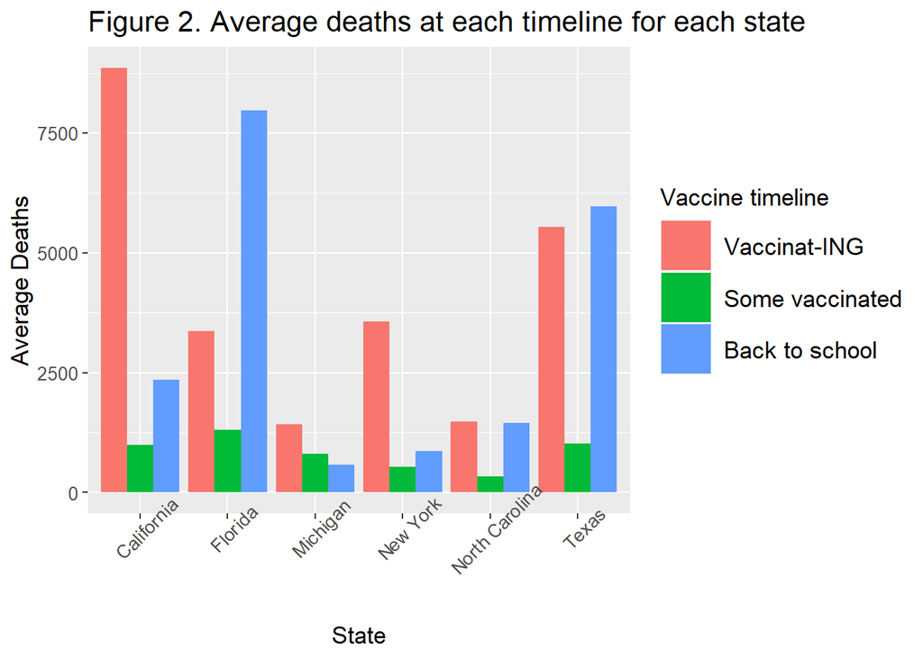

```r
d <- ggplot(data = barplot2, aes(x = Province, y = Average, fill = vaccine))
d + geom_bar(stat = "identity", position = "dodge") +
  labs(x = "State", y = "Average Deaths", title = "Figure 2. Average deaths at each timeline for each state") +
  scale_fill_discrete(name = "Vaccine timeline") +
  theme(axis.text.x = element_text(angle = 45, size = 10),
        axis.text.y = element_text(size = 10),
        axis.title.x = element_text(size = 13),
        axis.title.y = element_text(size = 13),
        legend.key.size = unit(1, 'cm'),
        legend.text = element_text(size = 13),
        title = element_text(size = 13))
```

#### 5.3.2. Box-Plots

Figure 3 and Figure 4 show the entire US data of active cases and deaths at each timeline. Note that each state has four dots in “vaccinat-ing” period, three dots in “some vaccinated” period and two dots in “back to school” period. So, there will be more data points in the first period than the second period and the third period. In addition, I apologize that due to the numerous outliers in both boxplots, I had to adjust the y-axis scales in order to see the median for each timeline.

Overall, Figure 3 shows that the median active cases is higher in the “back to school” period than in the “vaccinat-ing” period or “some vaccinated” period in US. The IQR block seems to be longer in the third period than it is in the first period. Again, we do not have enough information for the “back to school” period to confirm this. However, the median active cases is definitely the lowest and the IQR block is the smallest in the “some vaccinated” period in US compared to the other two timelines.

Figure 4 shows the median deaths is about the same in both “vaccinat-ing” period and “back to school” period with “back to school” IQR block being a little smaller than the “vaccinat-ing” IQR block. We need more information in the “back to school” period to be definite about this.

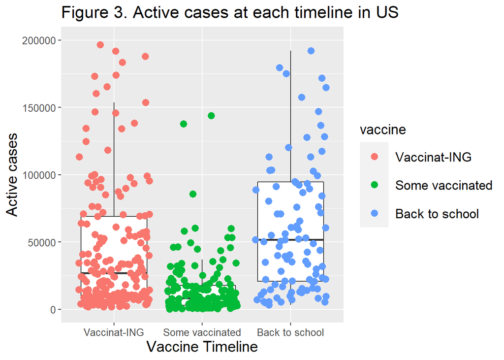

```r
boxplot1 <- ggplot(data = mydata3, aes(x = vaccine, y = Active))
boxplot1 + geom_boxplot(fill = "white", outlier.shape = NA) +
  coord_cartesian(ylim=c(0, 200000)) +
  geom_jitter(aes(color = vaccine), size = 3) +
  labs(x = "Vaccine Timeline", y = "Active cases", title = "Figure 3. Active cases at each timeline in US") +
  theme(axis.text.x = element_text(size = 10),
        axis.text.y = element_text(size = 10),
        axis.title.x = element_text(size = 15),
        axis.title.y = element_text(size = 15),
        legend.key.size = unit(1, 'cm'),
        legend.text = element_text(size = 13),
        title = element_text(size = 14))
```

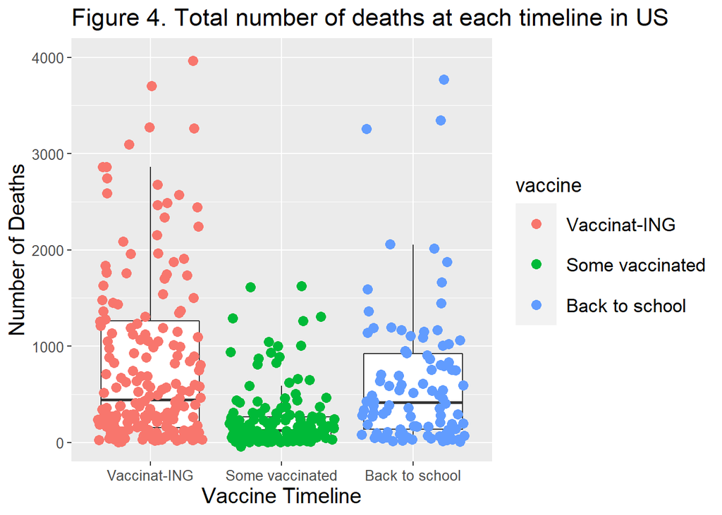

```r
boxplot2 <- ggplot(data = mydata3, aes(x = vaccine, y = Deaths))
boxplot2 + geom_boxplot(fill = "white", outlier.shape = NA) +
  coord_cartesian(ylim=c(0, 4000)) +
  geom_jitter(aes(color = vaccine), size = 3) +
  labs(x = "Vaccine Timeline", y = "Number of Deaths", title = "Figure 4. Total number of deaths at each timeline in US") +
  theme(axis.text.x = element_text(size = 10),
        axis.text.y = element_text(size = 10),
        axis.title.x = element_text(size = 15),
        axis.title.y = element_text(size = 15),
        legend.key.size = unit(1, 'cm'),
        legend.text = element_text(size = 13),
        title = element_text(size = 14))
```

#### 5.3.3. Scatterplot

Figure 5 scatterplot shows the relationship between number of active cases and number of deaths for different timelines in US. We can already guess that the relationship between active cases and deaths is a strong positive correlation. However, will that correlation stay the same between them for all vaccine time groups? Apparently not! Figure 5 indicates that in the “vaccinat-ing” period, the correlation between active cases and deaths is the strongest compared to the other two time groups. However, when the vaccine shots were taken place across US, approximately 40% of the population were vaccinated and together with the State-mandated restrictions during “some vaccinated” period, despite the increasing active cases, deaths were not imminent in this period. The active cases and number of deaths have the weakest correlation in the “some vaccinated” period.

Furthermore, despite also increased number of active cases in the “back to school” period, the correlation between number of deaths and active cases is still not nearly as strong as they are in the “vaccinat-ing” period. Table 6, the correlation table, coincides with our findings shown in Figure 5.

Once again, the plot is showing vaccines are helping the population to fight the virus. Despite students going back to schools and the more contagious and virulent Delta variant, the infected but fully vaccinated individuals may have better surviving odds against the virus. I apologize again that due to some large number outliters, I have to zoom-in on the action part to see the relationships better.

```r
sub1 <- mydata3 %>% filter(vaccine %in% c("Vaccinat-ING"))
sub2 <- mydata3 %>% filter(vaccine %in% c("Some vaccinated"))
sub3 <- mydata3 %>% filter(vaccine %in% c("Back to school"))

corr1 <- cor(sub1$Active, sub1$Deaths)
corr2 <- cor(sub2$Active, sub2$Deaths)
corr3 <- cor(sub3$Active, sub3$Deaths)
corr_all <- cbind(corr1, corr2, corr3)
kable(corr_all, digits = 4, col.names = c("Vaccinat-ING", "Some vaccinated", "Back to school"),
      caption = "Table 6, Correlations between active cases and deaths for each group")
```

Table 6, Correlations between active cases and deaths for each group

| Vaccinat-ING | Some vaccinated | Back to school |
| --- | --- | --- |
| 0.8814 | 0.6761 | 0.7897 |

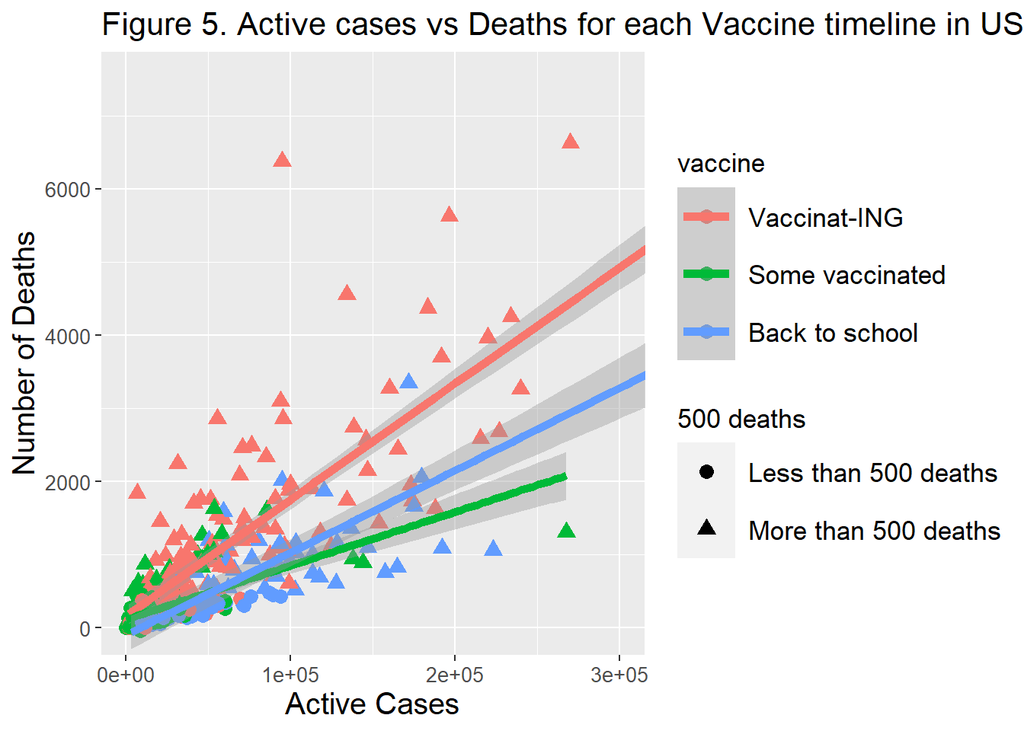

```r
scatter <- ggplot(data = mydata3, aes(x = Active, y = Deaths, color = vaccine))
scatter + geom_point(aes(shape = f500_deaths),size = 3) +
  scale_shape_discrete(name = "500 deaths") +
  coord_cartesian(xlim=c(0, 300000), ylim=c(0, 7500)) +
  geom_smooth(method = lm, lwd = 2) +
  labs(x = "Active Cases", y = "Number of Deaths", title = "Figure 5. Active cases vs Deaths for each Vaccine timeline in US") +
  theme(axis.text.x = element_text(size = 10),
        axis.text.y = element_text(size = 10),
        axis.title.x = element_text(size = 15),
        axis.title.y = element_text(size = 15),
        legend.key.size = unit(1, 'cm'),
        legend.text = element_text(size = 13),
        title = element_text(size = 13))
```

```r
#scale_fill_discrete(name = NULL)
```

#### 5.3.4.Histogram

Figure 6 shows histograms of number of deaths in US at different timelines. This may not be as helpful to us as the other plots. Remember there is one issue we addressed in the boxplots section. That is, there are twice as much data points in the “vaccinat-ing” period than in the “back to school” period since the “vaccinat-ing” period has four months of data for each state while the “back to school” period only has two months of data. Regardless, we see a significantly low deaths count in the “some vaccinated” period than the other two timelines. This says with approximately 40% of US population being vaccinated at least one shot and with the most state-mandated regulations on Covid-19 restrictions in the “some-vaccinated” period, we had a low deaths count in the same period.

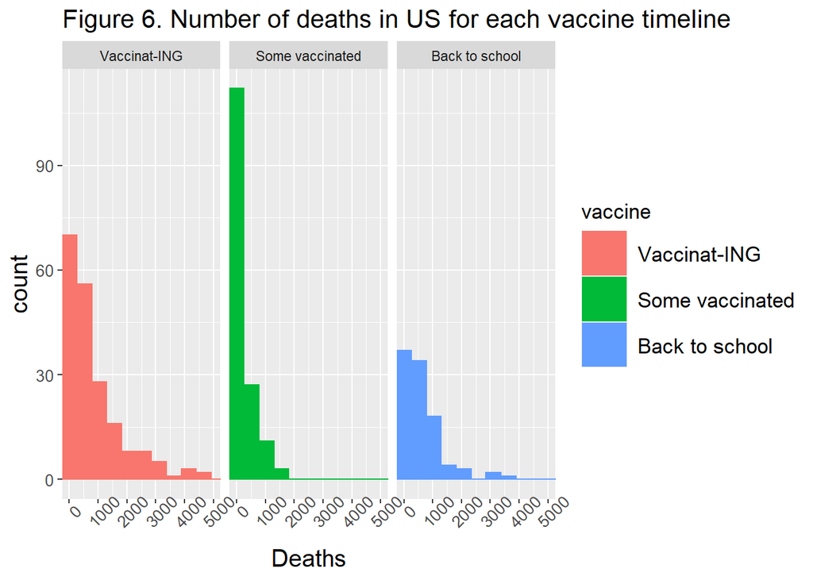

```r
his <- ggplot(data = mydata3, aes(x = Deaths, color = vaccine, fill = vaccine))
his + geom_histogram() +
  coord_cartesian(xlim=c(0, 5000)) +
  labs(title = "Figure 6. Number of deaths in US for each vaccine timeline") +
  theme(axis.text.x = element_text(angle= 45, size = 10),
        axis.text.y = element_text(size = 10),
        axis.title.x = element_text(size = 15),
        axis.title.y = element_text(size = 15),
        legend.key.size = unit(1, 'cm'),
        legend.text = element_text(size = 13),
        title = element_text(size = 13)) +
  facet_wrap(~vaccine)
```

#### 5.3.5. Line Plots

Figure 7 shows the total number of active cases each month in North Carolina and its neighbors since January 2021. The plot indicates the numbers were decreasing each month since January for every state and finally reached the minimum number of active cases so far for every state in June 2021. Then, the numbers were slowly going back up but then elevated when students went back to classroom and most states relaxed on their Covid-19 restrictions such as mask mandate and social distancing. This is reflected in the numerical summary shown in Table 4.

Figure 8 shows the total number of deaths each month in North Carolina and its neighbors since January 2021. This plot displays similar pattern as shown in Figure 7. Relatively speaking, North Carolina and some of its neighbors have less deaths in the later months than in the earlier months of 2021. Antibodies from the vaccine are helping the infected but vaccinated individuals to fight the virus. This is also reflected in the numerical summary shown in Table 5.

These plots tell us that despite the high-volume vaccine administration during the earlier months in 2021, State-mandated regulations on Covid-19 restrictions also helped greatly drive the number of cases and deaths down. Thus, we should continue to do so to help stop the community spread of the virus and get vaccine shots if people have not already.

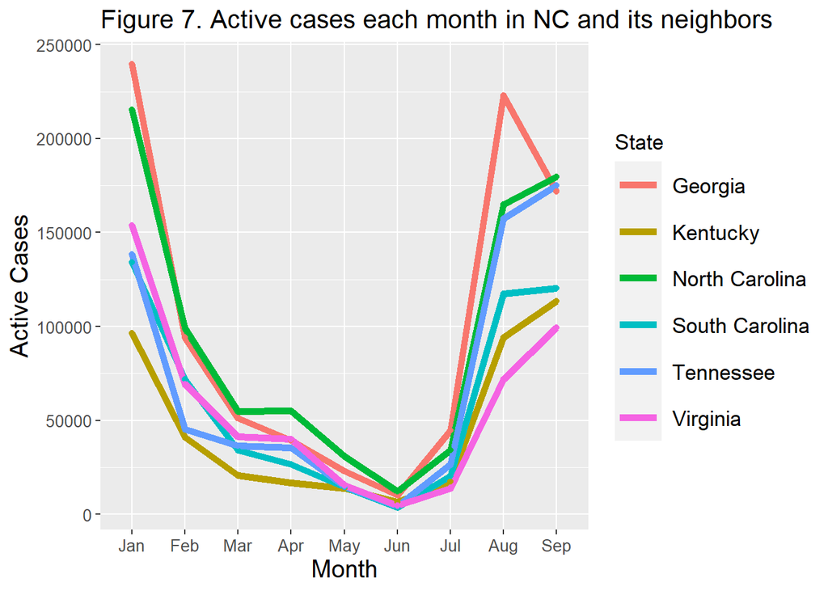

```r
mydata3$Month <- factor(mydata3$Month, levels = unique(mydata3$Month))
neighbor <- mydata3 %>% filter(State %in% c("North Carolina", "South Carolina", "Tennessee","Georgia", "Kentucky", "Virginia"))

lineplot1 <- ggplot(data = neighbor, aes(x = Month, y = Active, color = State))
lineplot1 + geom_line(aes(group = State), lwd = 2) + geom_point() +
  labs(y = "Active Cases", title = "Figure 7. Active cases each month in NC and its neighbors") +
  theme(axis.text.x = element_text(size = 10),
        axis.text.y = element_text(size = 10),
        axis.title.x = element_text(size = 15),
        axis.title.y = element_text(size = 15),
        legend.key.size = unit(1, 'cm'),
        legend.text = element_text(size = 13),
        title = element_text(size = 13))
```

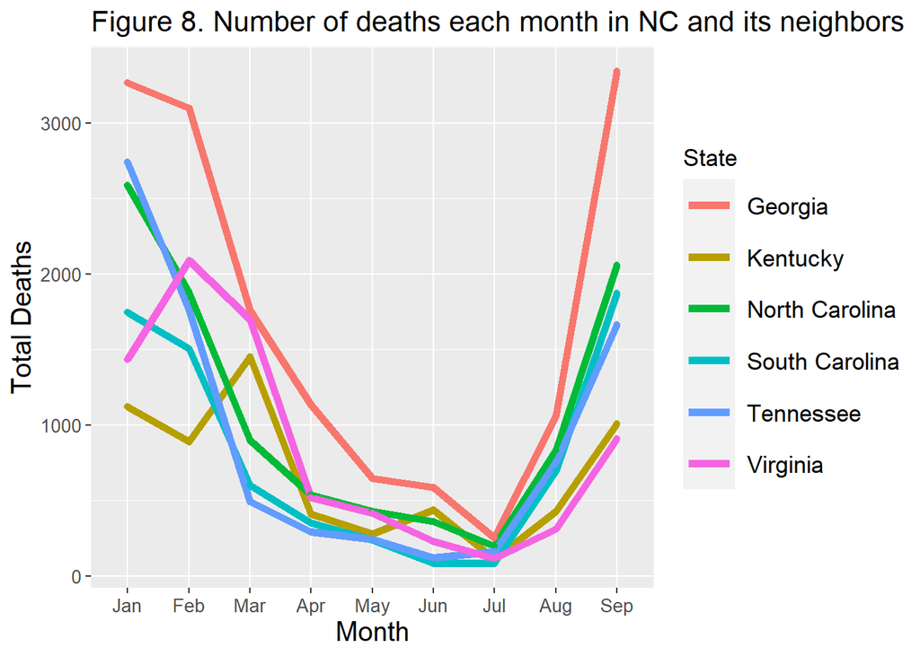

```r
lineplot2 <- ggplot(data = neighbor, aes(x = Month, y = Deaths, color = State))
lineplot2 + geom_line(aes(group = State), lwd = 2) + geom_point() +
  labs(y = "Total Deaths", title = "Figure 8. Number of deaths each month in NC and its neighbors") +
  theme(axis.text.x = element_text(size = 10),
        axis.text.y = element_text(size = 10),
        axis.title.x = element_text(size = 15),
        axis.title.y = element_text(size = 15),
        legend.key.size = unit(1, 'cm'),
        legend.text = element_text(size = 13),
        title = element_text(size = 13))
```

## 6. Conclusion

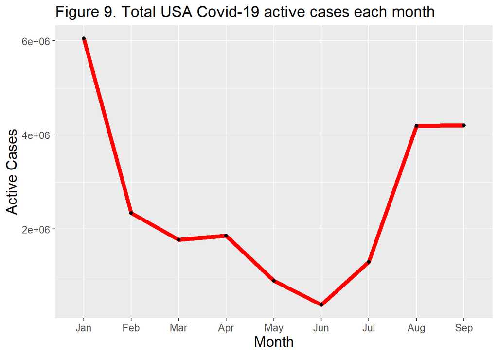

```r
#alldata
overall <- alldata %>% mutate(Active_cases = Active - Active2, Death = Deaths - Deaths2, Total = Confirmed - Confirmed2,
                   Month = rep(c("Jan", "Feb", "Mar", "Apr", "May", "Jun", "Jul", "Aug", "Sep")))
overall$Month <- factor(overall$Month, levels = unique(overall$Month))

lineplot3 <- ggplot(data = overall, aes(x = Month, y = Active_cases, group = 1))
lineplot3 + geom_line(lwd = 2, color = "red") + geom_point() +
  labs(y = "Active Cases", title = "Figure 9. Total USA Covid-19 active cases each month") +
  theme(axis.text.x = element_text(size = 10),
        axis.text.y = element_text(size = 10),
        axis.title.x = element_text(size = 15),
        axis.title.y = element_text(size = 15),
        title = element_text(size = 13))
```

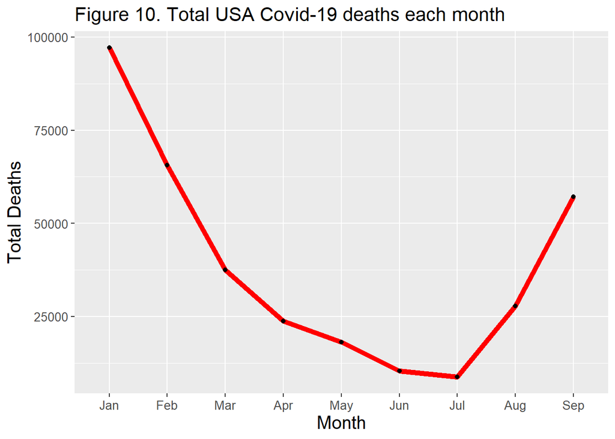

```r
lineplot4 <- ggplot(data = overall, aes(x = Month, y = Death, group = 1))
lineplot4 + geom_line(lwd = 2, color = "red") + geom_point() +
  labs(y = "Total Deaths", title = "Figure 10. Total USA Covid-19 deaths each month") +
  theme(axis.text.x = element_text(size = 10),
        axis.text.y = element_text(size = 10),
        axis.title.x = element_text(size = 15),
        axis.title.y = element_text(size = 15),
        title = element_text(size = 13))
```